# Introduction

This is my jupyter notebook for the deep learning class challenge of summer semester 2021. The challenge was the classification of google quickdraw images (https://quickdraw.withgoogle.com/). This notebook was a learning experience. I progressed from top to bottom and learned how to get better with each model I trained. Thats why maybe some models from the top aren't initially trained long enough or have other flaws that models further down below don't.

As this is a image classification task I will only try custom CNNs and transfer learning approaches. We have no use for recurrent or generative models.

# Part 1: The search for the right model

## Imports

```python
import tensorflow
import pandas as pd
import numpy as np
import time
import os
import json
from PIL import Image
import glob
from tqdm import tqdm
import matplotlib.pyplot as plt
%matplotlib inline

# My necessary imports
from tensorflow.keras.layers import InputLayer, Dense, Flatten, Dropout
from tensorflow.keras.layers import Conv2D
from tensorflow.keras.layers import MaxPooling2D
from tensorflow.keras.models import Sequential
from tensorflow.keras.optimizers import Adam
from tensorflow.keras.preprocessing.image import ImageDataGenerator
from tensorflow.keras.models import load_model
from tensorflow.keras.applications import Xception
from tensorflow.keras.applications import NASNetLarge
from tensorflow.keras.applications.inception_v3 import InceptionV3
from tensorflow.keras.preprocessing import image
from tensorflow.keras.models import Model
from tensorflow.keras.layers import Dense, GlobalAveragePooling2D
from tensorflow.keras.callbacks import EarlyStopping
from tensorflow.keras.callbacks import LearningRateScheduler
from tensorflow.keras.optimizers import SGD
from tensorflow.keras.optimizers import RMSprop

from keras.utils.data_utils import get_file

# !pip install keras-tuner
from kerastuner.applications import HyperResNet
from kerastuner.applications import HyperXception
from kerastuner.tuners import Hyperband
from kerastuner.tuners import RandomSearch
print(tensorflow.__version__)
```

```
2.5.0
```

## Data preprocessing

I split the images set into train and test folders by hand in the windows file explorer. I used a 80/20 split. The ImageDataGenerator (https://www.tensorflow.org/api_docs/python/tf/keras/preprocessing/image/ImageDataGenerator) automatically creates a matrix with the rescaled pixel values of the input image and a one hot coded array for the desired output based on folder structure. It was extremely helpful here and I am glad it was covered in the lectures.

```python
# Input dimensions of images
input_size = (28,28)
# Batch size
batch_size = 128 # https://stats.stackexchange.com/a/354512 this guy proposes that high batch size could
# jump over local minimum of gradient descend

# Noise data by zooming, rotating and flipping for more diverse training
train_datagen = ImageDataGenerator(rescale=1. / 255,
                                   shear_range=0.2,
                                   zoom_range=0.2,
                                   rotation_range=20,
                                   horizontal_flip=True)

# Don't noise test data since validation by Prof. Barra will be made on real noiseless data
test_datagen = ImageDataGenerator(rescale=1. / 255)

training_set = train_datagen.flow_from_directory('train_set',
                                                 color_mode='grayscale',
                                                 target_size=input_size,
                                                 batch_size=batch_size,
                                                 class_mode='categorical')

test_set = test_datagen.flow_from_directory('test_set',
                                            color_mode='grayscale',
                                            target_size=input_size,
                                            batch_size=batch_size,
                                            class_mode='categorical')
```

```
Found 80000 images belonging to 5 classes.
Found 20000 images belonging to 5 classes.
```

```python
print("The model class indices are:", training_set.class_indices)
```

```
The model class indices are: {'basket': 0, 'binoculars': 1, 'eye': 2, 'hand': 3, 'rabbit': 4}
```

```python
def evaluationPlotting(loaded_model, loaded_hist_acc, loaded_hist_val_acc, score, num_epochs):
    plt.figure(figsize=(15,8))
    plt.subplot(1,2,1)
    plt.plot(loaded_hist_acc)
    plt.plot(loaded_hist_val_acc)
    plt.title('Accuracy')
    plt.ylabel('Accuracy')
    plt.xlabel('epoch')
    plt.legend(['train', 'validation'], loc='best')

    plt.subplot(1,2,2)
    x = list(range(1,num_epochs+1))
    l = loaded_hist['loss']
    plt.xlabel('epoch')
    plt.ylabel('Cross entropy')
    plt.title("Test : Score = {0:5.3f}, Accuracy = {1:5.3f}".format(score[0], score[1]))
    plt.plot(x,l)
    plt.show()
    plt.tight_layout()
```

## Custom Sequential CNN from the training lecture on the MNIST dataset

Here I try the same network structure we used on the MNIST handwritten digits dataset in one of the training lectures. I got the idea when I noticed that the dimensions of the sketch images and the handwritten digits are the same.

```python
# Learning rate
learning_rate = 0.001
# Number of epochs
num_epochs = 10
# Dropout regularization (probability of neuron dropping out)
dropout = 0.1
```

```python
model = Sequential(name="custom_sequential_cnn")
model.add(InputLayer((28,28,1)))
model.add(Conv2D(32, kernel_size=(5, 5), activation="relu"))
model.add(MaxPooling2D(pool_size=(2, 2)))
model.add(Conv2D(64, kernel_size=(5, 5), activation="relu"))
model.add(MaxPooling2D(pool_size=(2, 2)))
model.add(Flatten())
model.add(Dropout(dropout))
model.add(Dense(5, activation="softmax"))
```

### Network structure visualisation

```python
model.summary()
```

```
Model: "custom_sequential_cnn"
_________________________________________________________________
Layer (type)                 Output Shape              Param #
=================================================================
conv2d_4 (Conv2D)            (None, 24, 24, 32)        832
_________________________________________________________________
max_pooling2d_4 (MaxPooling2 (None, 12, 12, 32)        0
_________________________________________________________________
conv2d_5 (Conv2D)            (None, 8, 8, 64)          51264
_________________________________________________________________
max_pooling2d_5 (MaxPooling2 (None, 4, 4, 64)          0
_________________________________________________________________
flatten_1 (Flatten)          (None, 1024)              0
_________________________________________________________________
dropout_1 (Dropout)          (None, 1024)              0
_________________________________________________________________
dense_1 (Dense)              (None, 5)                 5125
=================================================================
Total params: 57,221
Trainable params: 57,221
Non-trainable params: 0
_________________________________________________________________
```

```python
model.compile(loss="categorical_crossentropy", optimizer=Adam(learning_rate=learning_rate), metrics=["acc"])
```

```python
hist = model.fit(training_set, epochs=num_epochs, validation_data=test_set, workers=16)
```

### Evaluation

```python
# Save the model
model.save("saved_models/custom_sequential_cnn")
np.save("saved_models/custom_sequential_cnn/custom_sequential_cnn_history.npy", hist.history)
```

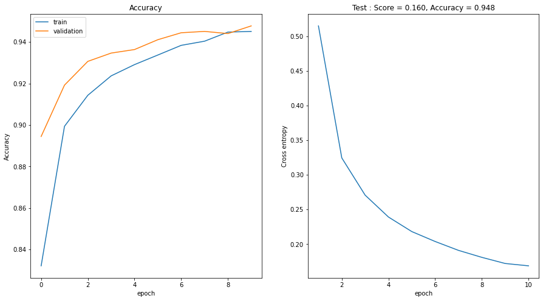

```python
# Load model
loaded_model = load_model("saved_models/custom_sequential_cnn")
loaded_hist=np.load("saved_models/custom_sequential_cnn/custom_sequential_cnn_history.npy", allow_pickle='TRUE').item()

# Compute the metrics in test mode
score = loaded_model.evaluate(test_set, verbose=0)

# Print the results
evaluationPlotting(loaded_model, loaded_hist['acc'], loaded_hist['val_acc'], score, num_epochs)
```

### Conclusion

A surprise for sure but a pleasent one. 94.77% accuracy on the test set with the first model I tried. Lucky for sure but this set the bar pretty high for future models. The graphs suggest that this model won't be improving much with further training.

### Appendix: Training for more epochs

I have just finished training the NasNet model which will come much later down the road. I have trained other models for far more than this one so in order to get a fair comparison I will now train this network for 50 epochs in total.

```python
# Load model
loaded_model = load_model("saved_models/custom_sequential_cnn")
```

```python
# Continue training on 40 more epochs
cnn_hist = loaded_model.fit(training_set, epochs=40, validation_data=test_set, workers=16)
```

```
...
```

```python
# Save the model
loaded_model.save("saved_models/custom_sequential_cnn_40_epochs")
np.save("saved_models/custom_sequential_cnn_40_epochs/custom_sequential_cnn_40_epochs_history.npy", cnn_hist.history)
```

```
INFO:tensorflow:Assets written to: saved_models/custom_sequential_cnn_40_epochs\assets
```

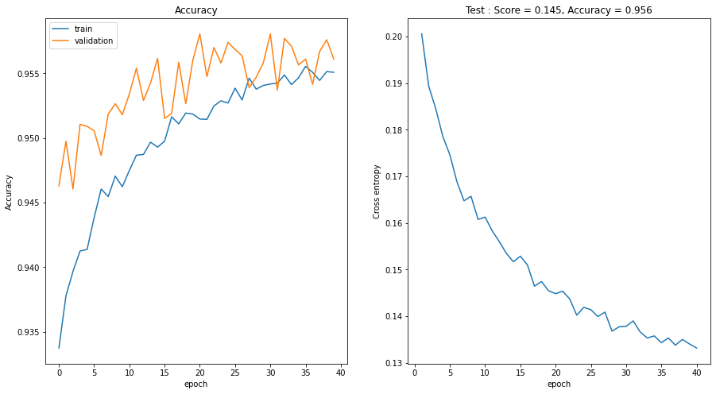

```python
# Load model
loaded_model = load_model("saved_models/custom_sequential_cnn_40_epochs")
loaded_hist=np.load("saved_models/custom_sequential_cnn_40_epochs/custom_sequential_cnn_40_epochs_history.npy", allow_pickle='TRUE').item()

# Compute the metrics in test mode
score = loaded_model.evaluate(test_set, verbose=0)
evaluationPlotting(loaded_model, loaded_hist['acc'], loaded_hist['val_acc'], score, 40)
```

## Custom CNN with random network structure search

In order to find the right amount of features per convolutional layer, the right value for the dropout percentage and learning rate I had the idea to use the Keras Tuner (https://github.com/keras-team/keras-tuner) This way I didnt have to change and retrain the model by hand to find the best combination.

```python
tuner_num_epochs = 10
```

```python
def build_model(hp):
    model = Sequential(name="custom_sequential_cnn_hyperparamter_search")
    model.add(InputLayer((28,28,1)))
    for i in range(hp.Int('num_layers', 1, 5)):
        model.add(Conv2D(hp.Int('filters_' + str(i), min_value=32, max_value=128, step=16), kernel_size=(5, 5),
                         activation='relu', padding="same"))
        model.add(MaxPooling2D(pool_size=(2, 2), padding="same"))
    model.add(Flatten())
    model.add(Dropout(hp.Float('dropout_chance', min_value=0.1, max_value=0.7, step=0.1)))
    model.add(Dense(5, activation='softmax'))
    model.compile(optimizer=Adam(hp.Choice('learning_rate', [1e-2, 1e-3, 1e-4])),
                  loss='categorical_crossentropy', metrics=['accuracy'])
    return model

# Predicted:
# 63 hours for 840 trials and 3 executions
# 10 hours for 220 trials and 2 executions
# Test:
# 11 hours for 177 trials and 2 executions
tuner = RandomSearch(
    build_model,
    objective='val_accuracy',
    max_trials=150,
    executions_per_trial=2,
    directory='custom_sequential_cnn_hyperparameter_search',
    project_name='custom_sequential_cnn_hyperparameter_search_project')

tuner.search_space_summary()
```

```
INFO:tensorflow:Reloading Oracle from existing project custom_sequential_cnn_hyperparameter_search\custom_sequential_cnn_hyperparameter_search_project\oracle.json
INFO:tensorflow:Reloading Tuner from custom_sequential_cnn_hyperparameter_search\custom_sequential_cnn_hyperparameter_search_project\tuner0.json
Search space summary
Default search space size: 8
num_layers (Int)
{'default': None, 'conditions': [], 'min_value': 1, 'max_value': 5, 'step': 1, 'sampling': None}
filters_0 (Int)
{'default': None, 'conditions': [], 'min_value': 32, 'max_value': 128, 'step': 16, 'sampling': None}
dropout_chance (Float)
{'default': 0.1, 'conditions': [], 'min_value': 0.1, 'max_value': 0.7, 'step': 0.1, 'sampling': None}
learning_rate (Choice)
{'default': 0.01, 'conditions': [], 'values': [0.01, 0.001, 0.0001], 'ordered': True}
filters_1 (Int)
{'default': None, 'conditions': [], 'min_value': 32, 'max_value': 128, 'step': 16, 'sampling': None}
filters_2 (Int)
{'default': None, 'conditions': [], 'min_value': 32, 'max_value': 128, 'step': 16, 'sampling': None}
filters_3 (Int)
{'default': None, 'conditions': [], 'min_value': 32, 'max_value': 128, 'step': 16, 'sampling': None}
filters_4 (Int)
{'default': None, 'conditions': [], 'min_value': 32, 'max_value': 128, 'step': 16, 'sampling': None}
```

```python
tuner.search(training_set, epochs=3, validation_data=test_set)
```

```python
tuner.results_summary()
```

```
Results summary
Results in custom_sequential_cnn_hyperparameter_search\custom_sequential_cnn_hyperparameter_search_project
Showing 10 best trials
Objective(name='val_accuracy', direction='max')
Trial summary
Hyperparameters:
num_layers: 4
filters_0: 112
dropout_chance: 0.2
learning_rate: 0.001
filters_1: 96
filters_2: 80
filters_3: 128
filters_4: 32
Score: 0.9562749862670898
...
Trial summary
Hyperparameters:
num_layers: 3
filters_0: 112
dropout_chance: 0.1
learning_rate: 0.001
filters_1: 96
filters_2: 64
filters_3: 128
filters_4: 64
Score: 0.9528999924659729
```

The random search has found a network structure and hyperparameter set that outperforms my inital CNN. A great success.

```python
tuner_model = tuner.get_best_models(num_models=1)
```

### Network strucutre visualisation

```python
tuner_model[0].summary()
```

```
Model: "custom_sequential_cnn_hyperparamter_search"
_________________________________________________________________
Layer (type)                 Output Shape              Param #
=================================================================
conv2d (Conv2D)              (None, 28, 28, 112)       2912
_________________________________________________________________
max_pooling2d (MaxPooling2D) (None, 14, 14, 112)       0
_________________________________________________________________
conv2d_1 (Conv2D)            (None, 14, 14, 96)        268896
_________________________________________________________________
max_pooling2d_1 (MaxPooling2 (None, 7, 7, 96)          0
_________________________________________________________________
conv2d_2 (Conv2D)            (None, 7, 7, 80)          192080
_________________________________________________________________
max_pooling2d_2 (MaxPooling2 (None, 4, 4, 80)          0
_________________________________________________________________
conv2d_3 (Conv2D)            (None, 4, 4, 128)         256128
_________________________________________________________________
max_pooling2d_3 (MaxPooling2 (None, 2, 2, 128)         0
_________________________________________________________________
flatten (Flatten)            (None, 512)               0
_________________________________________________________________
dropout (Dropout)            (None, 512)               0
_________________________________________________________________
dense (Dense)                (None, 5)                 2565
=================================================================
Total params: 722,581
Trainable params: 722,581
Non-trainable params: 0
_________________________________________________________________
```

```python
tuner_hist = tuner_model[0].fit(training_set, epochs=tuner_num_epochs, validation_data=test_set, workers=16)
```

```python
# Save the model
tuner_model[0].save("saved_models/custom_sequential_cnn_hyperparameter_search")
np.save("saved_models/custom_sequential_cnn_hyperparameter_search/custom_sequential_cnn_hyperparameter_search_history.npy", tuner_hist.history)
```

```
INFO:tensorflow:Assets written to: saved_models/custom_sequential_cnn_hyperparameter_search\assets
```

### Evaluation

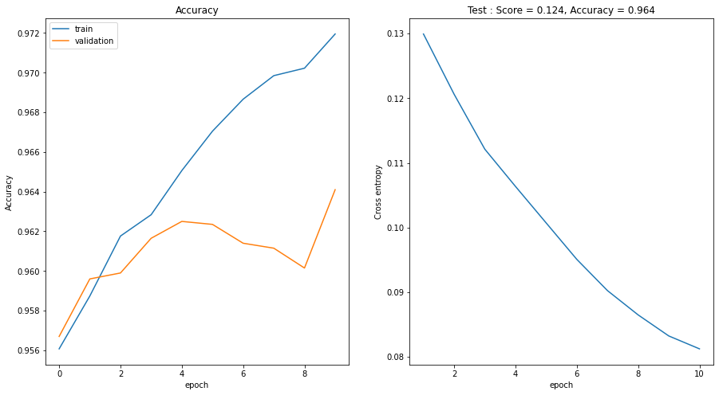

```python
# Load model
loaded_model = load_model("saved_models/custom_sequential_cnn_hyperparameter_search")
loaded_hist=np.load("saved_models/custom_sequential_cnn_hyperparameter_search/custom_sequential_cnn_hyperparameter_search_history.npy", allow_pickle='TRUE').item()

# Compute the metrics in test mode
score = loaded_model.evaluate(test_set, verbose=0)

# Print the results
evaluationPlotting(loaded_model, loaded_hist['accuracy'], loaded_hist['val_accuracy'], score, tuner_num_epochs)
```

### Conclusion

With 96.41% accuracy on the test set certainly a candidate for being the best model. The graphs suggest it will improve even more with more training. I will use the hyperband parameter search and add a dropout layer after each convolutional one to maybe find an even better network structure. I will try transfer learning first thought to get a better overview of alternatives.

### Appendix: Training for more epochs

After training the nasnet and the first custom squential cnn I have decided to give this model more training epochs aswell. Surprisingly the model found by hyperband was about as good as this randomly found one with seven times the training investment. My hopes are high here.

```python
# Load model
loaded_model = load_model("saved_models/custom_sequential_cnn_hyperparameter_search")
```

```python
# Continue training for 40 more epochs
cnn_hist = loaded_model.fit(training_set, epochs=40, validation_data=test_set, workers=16)
```

```python
# Save the model
loaded_model.save("saved_models/custom_sequential_cnn_hyperparameter_search_40_epochs")
np.save("saved_models/custom_sequential_cnn_hyperparameter_search_40_epochs/custom_sequential_cnn_hyperparameter_search_40_epochs_history.npy", cnn_hist.history)
```

```
INFO:tensorflow:Assets written to: saved_models/custom_sequential_cnn_hyperparameter_search_40_epochs\assets
```

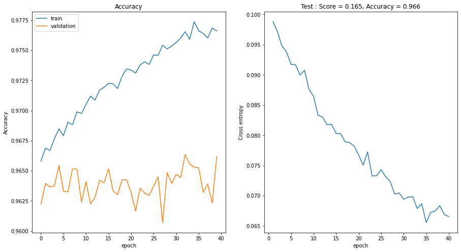

```python
# Load model
loaded_model = load_model("saved_models/custom_sequential_cnn_hyperparameter_search_40_epochs")
loaded_hist=np.load("saved_models/custom_sequential_cnn_hyperparameter_search_40_epochs/custom_sequential_cnn_hyperparameter_search_40_epochs_history.npy", allow_pickle='TRUE').item()

# Compute the metrics in test mode
score = loaded_model.evaluate(test_set, verbose=0)
evaluationPlotting(loaded_model, loaded_hist['accuracy'], loaded_hist['val_accuracy'], score, 40)
```

## Xception: A Transfer Learning Approach

In hope of finding a better network I will try to use the Xception Network (https://keras.io/api/applications/xception/) in transfer learning. In the lectures we saw that it is state-of-the-art, takes little FLOP-Operations compared to other state-of-the-art models and has a fairly small network size.

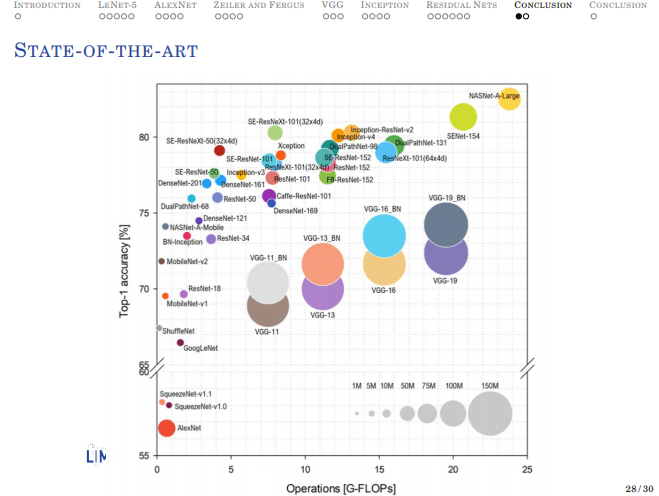

```python
xception_num_epochs = 60
stop_freeze = 4
xception_input_size = (71,71)
```

```python
def buildXception(stop_freeze):
    pretrained_model = Xception()

    # Suppression of the classification layer
    pretrained_model.layers.pop()

    # Freezing all the layers, except the last stop_freeze
    for layer in pretrained_model.layers[:-stop_freeze]:
        layer.trainable = False

    # New classifier on top of the network
    model = Sequential([pretrained_model, Flatten(), Dense(5, activation='softmax')], name="transfer_xception")
    return model


# Model
custom_xception = buildXception(stop_freeze = stop_freeze)
custom_xception.compile(loss="categorical_crossentropy", optimizer="adam", metrics=["accuracy"])
```

### Network structure visualisation

```python
custom_xception.summary()
```

```
Model: "transfer_xception"
_________________________________________________________________
Layer (type)                 Output Shape              Param #
=================================================================
xception (Functional)        (None, 1000)              22910480
_________________________________________________________________
flatten_2 (Flatten)          (None, 1000)              0
_________________________________________________________________
dense_2 (Dense)              (None, 5)                 5005
=================================================================
Total params: 22,915,485
Trainable params: 2,058,101
Non-trainable params: 20,857,384
_________________________________________________________________
```

The Xception model needs its input to be RGB and a minimum resolution of 71x71. Thats why we reload the data here. The ImageDataGenerator simply repeats the grayscale image for each channel and resizes by scaling up each one to 71x71.

```python
training_set_xception = train_datagen.flow_from_directory('train_set',
                                                 color_mode='rgb',
                                                 target_size=xception_input_size,
                                                 batch_size=batch_size,
                                                 class_mode='categorical')

test_set_xception = test_datagen.flow_from_directory('test_set',
                                            color_mode='rgb',
                                            target_size=xception_input_size,
                                            batch_size=batch_size,
                                            class_mode='categorical')
```

```
Found 80000 images belonging to 5 classes.
Found 20000 images belonging to 5 classes.
```

```python
xception_hist = custom_xception.fit(training_set_xception, epochs=xception_num_epochs, validation_data=test_set_xception, workers=16)
```

```
...
```

```python
# Save the model
custom_xception.save_weights("saved_models/transfer_learned_xception/weights.h5")
np.save("saved_models/transfer_learned_xception/transfer_learned_xception_history.npy", xception_hist.history)
```

### Evaluation

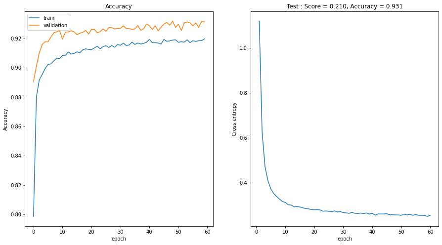

```python
loaded_model = buildXception(stop_freeze = stop_freeze)
loaded_model.compile(loss="categorical_crossentropy", optimizer="adam", metrics=["accuracy"])

loaded_model.load_weights("saved_models/transfer_learned_xception/weights.h5")
loaded_hist=np.load("saved_models/transfer_learned_xception/transfer_learned_xception_history.npy", allow_pickle='TRUE').item()

# Compute the metrics in test mode
score = loaded_model.evaluate(test_set_xception, verbose=0)

# Print the results
evaluationPlotting(loaded_model, loaded_hist['accuracy'], loaded_hist['val_accuracy'], score, xception_num_epochs)
```

### Conclusion

Sadly even after 60 epochs the model only gets to 93.12 % accuracy on the test set. Good but worse than the custom cnns.

## HyperResNet: Trying to find a suitable network structure similar to the ResNet

The Keras Tuner provides a hyperband (https://arxiv.org/abs/1603.06560) parameter and network strucutre optimzier that builds on the resnet model strucutre (https://keras-team.github.io/keras-tuner/documentation/hypermodels/#hyperresnet-class). I am hoping by using the hyperband algorithm and relying on the proven resnet, a better network structure will be found.

```python
hyperresnet_tuner_num_epochs = 5

def buildHyperResnetTuner():
    hyperresnet = HyperResNet(input_shape=(28, 28, 1), classes=5)
    hyperresnet_tuner = Hyperband(hyperresnet, objective='val_accuracy', max_epochs=40,
        directory='resnet_hyperband_parameter_search',
        project_name='resnet_hyperband_parameter_search_project')
    return hyperresnet_tuner

hyperresnet_tuner = buildHyperResnetTuner()
hyperresnet_tuner.search_space_summary()
```

```
INFO:tensorflow:Reloading Oracle from existing project resnet_hyperband_parameter_search\resnet_hyperband_parameter_search_project\oracle.json
INFO:tensorflow:Reloading Tuner from resnet_hyperband_parameter_search\resnet_hyperband_parameter_search_project\tuner0.json
Search space summary
Default search space size: 6
version (Choice)
{'default': 'v2', 'conditions': [], 'values': ['v1', 'v2', 'next'], 'ordered': False}
conv3_depth (Choice)
{'default': 4, 'conditions': [], 'values': [4, 8], 'ordered': True}
conv4_depth (Choice)
{'default': 6, 'conditions': [], 'values': [6, 23, 36], 'ordered': True}
pooling (Choice)
{'default': 'avg', 'conditions': [], 'values': ['avg', 'max'], 'ordered': False}
optimizer (Choice)
{'default': 'adam', 'conditions': [], 'values': ['adam', 'rmsprop', 'sgd'], 'ordered': False}
learning_rate (Choice)
{'default': 0.01, 'conditions': [], 'values': [0.1, 0.01, 0.001], 'ordered': True}
```

```python
#Trial 30 Complete [00h 06m 20s]
#Best val_accuracy So Far: 0.9074000120162964
#Total elapsed time: 04h 06m 55s

hyperresnet_tuner.search(training_set, validation_data=test_set)
```

```python
hyperresnet_tuner.results_summary()
hyperresnet_tuner_model = hyperresnet_tuner.get_best_models(num_models=1)
```

```
Results summary
Results in resnet_hyperband_parameter_search\resnet_hyperband_parameter_search_project
Showing 10 best trials
Objective(name='val_accuracy', direction='max')
Trial summary
Hyperparameters:
version: v1
conv3_depth: 4
conv4_depth: 6
pooling: avg
optimizer: rmsprop
learning_rate: 0.001
tuner/epochs: 2
tuner/initial_epoch: 0
tuner/bracket: 3
tuner/round: 0
Score: 0.9074000120162964
...
Trial summary
Hyperparameters:
version: next
conv3_depth: 8
conv4_depth: 6
pooling: max
optimizer: sgd
learning_rate: 0.01
tuner/epochs: 2
tuner/initial_epoch: 0
tuner/bracket: 3
tuner/round: 0
Score: 0.8581500053405762
```

### Network structure visualisation

```python
hyperresnet_tuner_model[0].summary()
```

```
Model: "ResNet"
__________________________________________________________________________________________________
Layer (type)                    Output Shape         Param #     Connected to
==================================================================================================
input_1 (InputLayer)            [(None, 28, 28, 1)]  0
__________________________________________________________________________________________________
conv1_pad (ZeroPadding2D)       (None, 34, 34, 1)    0           input_1[0][0]
__________________________________________________________________________________________________
conv1_conv (Conv2D)             (None, 14, 14, 64)   3200        conv1_pad[0][0]
__________________________________________________________________________________________________
conv1_bn (BatchNormalization)   (None, 14, 14, 64)   256         conv1_conv[0][0]
__________________________________________________________________________________________________
conv1_relu (Activation)         (None, 14, 14, 64)   0           conv1_bn[0][0]
__________________________________________________________________________________________________
pool1_pad (ZeroPadding2D)       (None, 16, 16, 64)   0           conv1_relu[0][0]
__________________________________________________________________________________________________
pool1_pool (MaxPooling2D)       (None, 7, 7, 64)     0           pool1_pad[0][0]
__________________________________________________________________________________________________
conv2_block1_1_conv (Conv2D)    (None, 7, 7, 64)     4160        pool1_pool[0][0]
__________________________________________________________________________________________________
conv2_block1_1_bn (BatchNormali (None, 7, 7, 64)     256         conv2_block1_1_conv[0][0]
__________________________________________________________________________________________________
conv2_block1_1_relu (Activation (None, 7, 7, 64)     0           conv2_block1_1_bn[0][0]
__________________________________________________________________________________________________
conv2_block1_2_conv (Conv2D)    (None, 7, 7, 64)     36928       conv2_block1_1_relu[0][0]
__________________________________________________________________________________________________
conv2_block1_2_bn (BatchNormali (None, 7, 7, 64)     256         conv2_block1_2_conv[0][0]
__________________________________________________________________________________________________
conv2_block1_2_relu (Activation (None, 7, 7, 64)     0           conv2_block1_2_bn[0][0]
__________________________________________________________________________________________________
conv2_block1_0_conv (Conv2D)    (None, 7, 7, 256)    16640       pool1_pool[0][0]
__________________________________________________________________________________________________
conv2_block1_3_conv (Conv2D)    (None, 7, 7, 256)    16640       conv2_block1_2_relu[0][0]
__________________________________________________________________________________________________
conv2_block1_0_bn (BatchNormali (None, 7, 7, 256)    1024        conv2_block1_0_conv[0][0]
__________________________________________________________________________________________________
conv2_block1_3_bn (BatchNormali (None, 7, 7, 256)    1024        conv2_block1_3_conv[0][0]
__________________________________________________________________________________________________
conv2_block1_add (Add)          (None, 7, 7, 256)    0           conv2_block1_0_bn[0][0]
                                                                 conv2_block1_3_bn[0][0]
...
conv5_block3_out (Activation)   (None, 1, 1, 2048)   0           conv5_block3_add[0][0]
__________________________________________________________________________________________________
avg_pool (GlobalAveragePooling2 (None, 2048)         0           conv5_block3_out[0][0]
__________________________________________________________________________________________________
probs (Dense)                   (None, 5)            10245       avg_pool[0][0]
==================================================================================================
Total params: 23,591,685
Trainable params: 23,538,565
Non-trainable params: 53,120
__________________________________________________________________________________________________
```

```python
hyperresnet_tuner_hist = hyperresnet_tuner_model[0].fit(training_set, epochs=hyperresnet_tuner_num_epochs, validation_data=test_set, workers=16)
```

```python
# Save the model
hyperresnet_tuner_model[0].save_weights("saved_models/transfer_learned_resnet_hyperband_optimization/weights.h5")
np.save("saved_models/transfer_learned_resnet_hyperband_optimization/transfer_learned_resnet_hyperband_optimization_history.npy", hyperresnet_tuner_hist.history)
```

### Evaluation

```
INFO:tensorflow:Reloading Oracle from existing project resnet_hyperband_parameter_search\resnet_hyperband_parameter_search_project\oracle.json
INFO:tensorflow:Reloading Tuner from resnet_hyperband_parameter_search\resnet_hyperband_parameter_search_project\tuner0.json
```

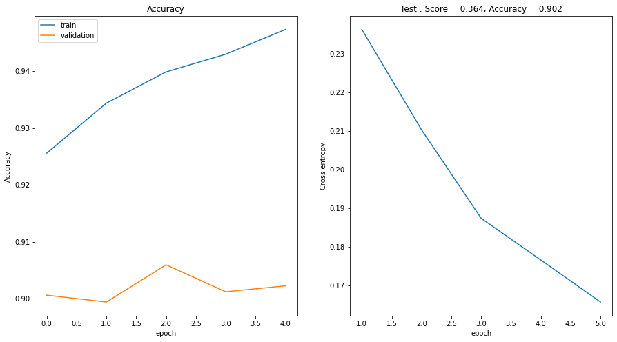

```python
# Load model
hyperresnet_tuner_evaluation = buildHyperResnetTuner()
loaded_model = hyperresnet_tuner_evaluation.get_best_models(num_models=1)[0]

loaded_model.load_weights("saved_models/transfer_learned_resnet_hyperband_optimization/weights.h5")
loaded_hist=np.load("saved_models/transfer_learned_resnet_hyperband_optimization/transfer_learned_resnet_hyperband_optimization_history.npy", allow_pickle='TRUE').item()


# Compute the metrics in test mode
score = loaded_model.evaluate(test_set, verbose=0)

# Print the results
evaluationPlotting(loaded_model, loaded_hist['accuracy'], loaded_hist['val_accuracy'], score, hyperresnet_tuner_num_epochs)
```

### Conclusion

Even though the hyperband optimization found a good network structure similar to ResNet it did not outperform the custom sequential cnn that was found via random optimization by 6%. The graphs suggest that this network won't improve with more training or if so it will do so very slowly (seems like it's just overfitting at this point) so I will try different approaches first before investing more time into this one. I think this was an overkill. I think I do not have the hardware resources to properly train a network of this size.

## Custom CNN with Hyperband search

After finding out about the effectiveness of hyperband search I will continue with my custom CNN idea and try to find an even better network structure than with random search.

```python
hyperband_cnn_num_epochs = 30

def build_hyperband_cnn(hp):
    model = Sequential(name="custom_hyperband_cnn")
    model.add(InputLayer((28,28,1)))
    for i in range(hp.Int('num_layers', 1, 5)):
        model.add(Conv2D(hp.Int('filters_' + str(i), min_value=32, max_value=128, step=16), kernel_size=(5, 5),
                         activation='relu', padding="same"))
        model.add(MaxPooling2D(pool_size=(2, 2), padding="same"))
        model.add(Dropout(hp.Float('dropout_chance_' + str(i), min_value=0.1, max_value=0.7, step=0.1)))
    model.add(Flatten())
    model.add(Dropout(hp.Float('dropout_chance', min_value=0.1, max_value=0.7, step=0.1)))
    model.add(Dense(5, activation='softmax'))
    model.compile(optimizer=Adam(hp.Choice('learning_rate', [1e-2, 1e-3, 1e-4])),
                  loss='categorical_crossentropy', metrics=['accuracy'])
    return model

hyperbandcnn_tuner = Hyperband(
    build_hyperband_cnn,
    objective='val_accuracy',
    max_epochs=40,
    hyperband_iterations=5,
    directory='custom_hyperband_cnn',
    project_name='custom_hyperband_cnn_project')


hyperbandcnn_tuner.search_space_summary()
```

```
INFO:tensorflow:Reloading Oracle from existing project custom_hyperband_cnn\custom_hyperband_cnn_project\oracle.json
INFO:tensorflow:Reloading Tuner from custom_hyperband_cnn\custom_hyperband_cnn_project\tuner0.json
Search space summary
Default search space size: 13
num_layers (Int)
{'default': None, 'conditions': [], 'min_value': 1, 'max_value': 5, 'step': 1, 'sampling': None}
filters_0 (Int)
{'default': None, 'conditions': [], 'min_value': 32, 'max_value': 128, 'step': 16, 'sampling': None}
dropout_chance_0 (Float)
{'default': 0.1, 'conditions': [], 'min_value': 0.1, 'max_value': 0.7, 'step': 0.1, 'sampling': None}
dropout_chance (Float)
{'default': 0.1, 'conditions': [], 'min_value': 0.1, 'max_value': 0.7, 'step': 0.1, 'sampling': None}
learning_rate (Choice)
{'default': 0.01, 'conditions': [], 'values': [0.01, 0.001, 0.0001], 'ordered': True}
filters_1 (Int)
{'default': None, 'conditions': [], 'min_value': 32, 'max_value': 128, 'step': 16, 'sampling': None}
dropout_chance_1 (Float)
{'default': 0.1, 'conditions': [], 'min_value': 0.1, 'max_value': 0.7, 'step': 0.1, 'sampling': None}
filters_2 (Int)
{'default': None, 'conditions': [], 'min_value': 32, 'max_value': 128, 'step': 16, 'sampling': None}
dropout_chance_2 (Float)
{'default': 0.1, 'conditions': [], 'min_value': 0.1, 'max_value': 0.7, 'step': 0.1, 'sampling': None}
filters_3 (Int)
{'default': None, 'conditions': [], 'min_value': 32, 'max_value': 128, 'step': 16, 'sampling': None}
dropout_chance_3 (Float)
{'default': 0.1, 'conditions': [], 'min_value': 0.1, 'max_value': 0.7, 'step': 0.1, 'sampling': None}
filters_4 (Int)
{'default': None, 'conditions': [], 'min_value': 32, 'max_value': 128, 'step': 16, 'sampling': None}
dropout_chance_4 (Float)
{'default': 0.1, 'conditions': [], 'min_value': 0.1, 'max_value': 0.7, 'step': 0.1, 'sampling': None}
```

```python
hyperbandcnn_tuner.search(training_set, validation_data=test_set)
```

```
Trial 90 Complete [00h 23m 06s]
val_accuracy: 0.9011499881744385

Best val_accuracy So Far: 0.9647499918937683
Total elapsed time: 07h 51m 09s
INFO:tensorflow:Oracle triggered exit
```

```python
hyperbandcnn_tuner.results_summary()
hyperbandcnn_tuner_model = hyperbandcnn_tuner.get_best_models(num_models=1)
```

```
Results summary
Results in custom_hyperband_cnn\custom_hyperband_cnn_project
Showing 10 best trials
Objective(name='val_accuracy', direction='max')
Trial summary
Hyperparameters:
num_layers: 4
filters_0: 96
dropout_chance_0: 0.4
dropout_chance: 0.5
learning_rate: 0.001
filters_1: 64
dropout_chance_1: 0.1
filters_2: 112
dropout_chance_2: 0.2
filters_3: 80
dropout_chance_3: 0.2
filters_4: 64
dropout_chance_4: 0.5
tuner/epochs: 40
tuner/initial_epoch: 14
tuner/bracket: 2
tuner/round: 2
tuner/trial_id: ad5db7e292b74a93dce5502be7f7de72
Score: 0.9647499918937683
...
Trial summary
Hyperparameters:
num_layers: 5
filters_0: 80
dropout_chance_0: 0.7000000000000001
dropout_chance: 0.1
learning_rate: 0.0001
filters_1: 96
dropout_chance_1: 0.1
filters_2: 96
dropout_chance_2: 0.5
filters_3: 48
dropout_chance_3: 0.5
filters_4: 80
dropout_chance_4: 0.4
tuner/epochs: 40
tuner/initial_epoch: 0
tuner/bracket: 0
tuner/round: 0
Score: 0.9592000246047974
```

### Network structure visualisation

```python
hyperbandcnn_tuner_model[0].summary()
```

```
Model: "custom_hyperband_cnn"
_________________________________________________________________
Layer (type)                 Output Shape              Param #
=================================================================
conv2d (Conv2D)              (None, 28, 28, 96)        2496
_________________________________________________________________
max_pooling2d (MaxPooling2D) (None, 14, 14, 96)        0
_________________________________________________________________
dropout (Dropout)            (None, 14, 14, 96)        0
_________________________________________________________________
conv2d_1 (Conv2D)            (None, 14, 14, 64)        153664
_________________________________________________________________
max_pooling2d_1 (MaxPooling2 (None, 7, 7, 64)          0
_________________________________________________________________
dropout_1 (Dropout)          (None, 7, 7, 64)          0
_________________________________________________________________
conv2d_2 (Conv2D)            (None, 7, 7, 112)         179312
_________________________________________________________________
max_pooling2d_2 (MaxPooling2 (None, 4, 4, 112)         0
_________________________________________________________________
dropout_2 (Dropout)          (None, 4, 4, 112)         0
_________________________________________________________________
conv2d_3 (Conv2D)            (None, 4, 4, 80)          224080
_________________________________________________________________
max_pooling2d_3 (MaxPooling2 (None, 2, 2, 80)          0
_________________________________________________________________
dropout_3 (Dropout)          (None, 2, 2, 80)          0
_________________________________________________________________
flatten (Flatten)            (None, 320)               0
_________________________________________________________________
dropout_4 (Dropout)          (None, 320)               0
_________________________________________________________________
dense (Dense)                (None, 5)                 1605
=================================================================
Total params: 561,157
Trainable params: 561,157
Non-trainable params: 0
_________________________________________________________________
```

```python
hyperbandcnn_tuner_hist = hyperbandcnn_tuner_model[0].fit(training_set, epochs=hyperband_cnn_num_epochs, validation_data=test_set, workers=16)
```

```python
# Save the model
hyperbandcnn_tuner_model[0].save("saved_models/custom_hyperband_cnn")
np.save("saved_models/custom_hyperband_cnn/custom_hyperband_cnn_history.npy", hyperbandcnn_tuner_hist.history)
```

```
INFO:tensorflow:Assets written to: saved_models/custom_hyperband_cnn\assets
```

### Evaluation

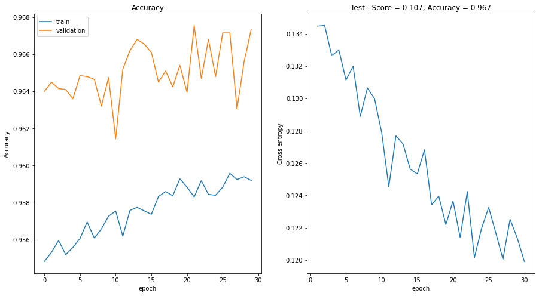

```python
# Load model
loaded_model = load_model("saved_models/custom_hyperband_cnn")
loaded_hist=np.load("saved_models/custom_hyperband_cnn/custom_hyperband_cnn_history.npy", allow_pickle='TRUE').item()

# Compute the metrics in test mode
score = loaded_model.evaluate(test_set, verbose=0)

# Print the results
evaluationPlotting(loaded_model, loaded_hist['accuracy'], loaded_hist['val_accuracy'], score, hyperband_cnn_num_epochs)
```

### Conclusion

The graphs aren't very representing for the entire training process since the hyperband algorithm already trained the network for 40 epochs. So the graphs represent epoch 41 to 70. But nonetheless I beat my best model up until this point!

## NasNetLarge: A second transfer learning approach

I'll throw in another transfer learning approach here. In the lecture we saw that the NasNet is the most accurate state-of-the-art model. I am eager to try it for my problem.

```python
nasnet_num_epochs = 30
stop_freeze = 4
nasnet_input_size = (32,32)
```

```python
def buildNasNet(stop_freeze):
    pretrained_model = NASNetLarge(weights=None, input_shape=(*nasnet_input_size, 3), include_top=False)
    weights_file = get_file("NASNet-large-no-top.h5", "https://github.com/titu1994/Keras-NASNet/"
    "releases/download/v1.1/NASNet-large-no-top.h5")
    pretrained_model.load_weights(weights_file)

    # Suppression of the classification layer
    pretrained_model.layers.pop()

    # Freezing all the layers, except the last stop_freeze
    for layer in pretrained_model.layers[:-stop_freeze]:
        layer.trainable = False

    # New classifier on top of the network
    model = Sequential([pretrained_model, Flatten(), Dense(5, activation='softmax')], name="transfer_nasnet")
    return model


# Model
custom_nasnet = buildNasNet(stop_freeze = stop_freeze)
custom_nasnet.compile(loss="categorical_crossentropy", optimizer="adam", metrics=["accuracy"])
```

### Network structure visualisation

```python
custom_nasnet.summary()
```

```
Model: "transfer_nasnet"
_________________________________________________________________
Layer (type)                 Output Shape              Param #
=================================================================
NASNet (Functional)          (None, 1, 1, 4032)        84916818
_________________________________________________________________
flatten_1 (Flatten)          (None, 4032)              0
_________________________________________________________________
dense_1 (Dense)              (None, 5)                 20165
=================================================================
Total params: 84,936,983
Trainable params: 20,165
Non-trainable params: 84,916,818
_________________________________________________________________
```

Similar to the Xception model the NASNet requires a minimum image size of 32x32 and three color channels. The imagedatagenerator helps here.

```python
training_set_nasnet = train_datagen.flow_from_directory('train_set',
                                                 color_mode='rgb',
                                                 target_size=nasnet_input_size,
                                                 batch_size=batch_size,
                                                 class_mode='categorical')

test_set_nasnet = test_datagen.flow_from_directory('test_set',
                                            color_mode='rgb',
                                            target_size=nasnet_input_size,
                                            batch_size=batch_size,
                                            class_mode='categorical')
```

```
Found 80000 images belonging to 5 classes.
Found 20000 images belonging to 5 classes.
```

```python
nasnet_hist = custom_nasnet.fit(training_set_nasnet, epochs=nasnet_num_epochs, validation_data=test_set_nasnet, workers=16)
```

```
...
```

```python
# Save the model
custom_nasnet.save_weights("saved_models/transfer_learned_nasnet/weights.h5")
np.save("saved_models/transfer_learned_nasnet/transfer_learned_nasnet_history.npy", nasnet_hist.history)
```

### Evaluation

```python
loaded_model = buildNasNet(stop_freeze = stop_freeze)
loaded_model.compile(loss="categorical_crossentropy", optimizer="adam", metrics=["accuracy"])

loaded_model.load_weights("saved_models/transfer_learned_nasnet/weights.h5")
loaded_hist=np.load("saved_models/transfer_learned_nasnet/transfer_learned_nasnet_history.npy", allow_pickle='TRUE').item()

# Compute the metrics in test mode
score = loaded_model.evaluate(test_set_nasnet, verbose=0)

# Print the results
evaluationPlotting(loaded_model, loaded_hist['accuracy'], loaded_hist['val_accuracy'], score, nasnet_num_epochs)
```

[output not shown]

### Conclusion

So the NasNet performed horribly. Only 50% accuary on the test set which is a bit more than twice as good as guessing... It could be that I have to unfreeze more layers or train for a longer period of time to improve but this performed so badly and took so long to train I will not continue to investigate this further.

## InceptionV3: A 3rd transfer learning approach

This is going to be the last transfer learning approach I will try. I have found some code on how to "fine-tune" a InceptionV3 model (https://keras.io/api/applications/) and I am eager to try. I am hoping to maybe learn about mistakes I have made with transfer learning before (Xception had 93% so it wasn't that bad).

```python
inceptionv3_epochs = 5
```

```python
# create the base pre-trained model
base_model = InceptionV3(weights='imagenet', include_top=False)

# add a global spatial average pooling layer
x = base_model.output
x = GlobalAveragePooling2D()(x)
# let's add a fully-connected layer
x = Dense(1024, activation='relu')(x)
# and a logistic layer -- let's say we have 5 classes
predictions = Dense(5, activation='softmax')(x)

# this is the model we will train
model = Model(inputs=base_model.input, outputs=predictions)

# first: train only the top layers (which were randomly initialized)
# i.e. freeze all convolutional InceptionV3 layers
for layer in base_model.layers:
    layer.trainable = False

# compile the model (should be done *after* setting layers to non-trainable)
model.compile(optimizer='rmsprop', loss='categorical_crossentropy')
```

### Network structure visualisation

```python
model.summary()
```

```
Model: "model"
__________________________________________________________________________________________________
Layer (type)                    Output Shape         Param #     Connected to
==================================================================================================
input_1 (InputLayer)            [(None, None, None,  0
__________________________________________________________________________________________________
conv2d (Conv2D)                 (None, None, None, 3 864         input_1[0][0]
__________________________________________________________________________________________________
batch_normalization (BatchNorma (None, None, None, 3 96          conv2d[0][0]
__________________________________________________________________________________________________
activation (Activation)         (None, None, None, 3 0           batch_normalization[0][0]
__________________________________________________________________________________________________
conv2d_1 (Conv2D)               (None, None, None, 3 9216        activation[0][0]
__________________________________________________________________________________________________
batch_normalization_1 (BatchNor (None, None, None, 3 96          conv2d_1[0][0]
...
global_average_pooling2d (Globa (None, 2048)         0           mixed10[0][0]
__________________________________________________________________________________________________
dense (Dense)                   (None, 1024)         2098176     global_average_pooling2d[0][0]
__________________________________________________________________________________________________
dense_1 (Dense)                 (None, 5)            5125        dense[0][0]
==================================================================================================
Total params: 23,906,085
Trainable params: 2,103,301
Non-trainable params: 21,802,784
__________________________________________________________________________________________________
```

```python
# We have to again reload our data as RGB
training_set_inceptionv3 = train_datagen.flow_from_directory('train_set',
                                                 color_mode='rgb',
                                                 target_size=(75,75),
                                                 batch_size=batch_size,
                                                 class_mode='categorical')

test_set_inceptionv3 = test_datagen.flow_from_directory('test_set',
                                            color_mode='rgb',
                                            target_size=(75,75),
                                            batch_size=batch_size,
                                            class_mode='categorical')
```

```
Found 80000 images belonging to 5 classes.
Found 20000 images belonging to 5 classes.
```

```python
# train the model on the new data for a few epochs
inceptionv3_hist = model.fit(training_set_inceptionv3, epochs=inceptionv3_epochs, validation_data=test_set_inceptionv3, callbacks=[EarlyStopping(monitor='val_accuracy', mode='max', min_delta=1)], workers=16)
```

[output not shown]

```python
# at this point, the top layers are well trained and we can start fine-tuning
# convolutional layers from inception V3. We will freeze the bottom N layers
# and train the remaining top layers.

# let's visualize layer names and layer indices to see how many layers
# we should freeze:
for i, layer in enumerate(base_model.layers):
   print(i, layer.name)

# we chose to train the top 2 inception blocks, i.e. we will freeze
# the first 249 layers and unfreeze the rest:
for layer in model.layers[:249]:
   layer.trainable = False
for layer in model.layers[249:]:
   layer.trainable = True

# we need to recompile the model for these modifications to take effect
# we use SGD with a low learning rate
model.compile(optimizer=SGD(learning_rate=0.0001, momentum=0.9), loss='categorical_crossentropy', metrics=["accuracy"])
```

```
0 input_1
1 conv2d
2 batch_normalization
3 activation
4 conv2d_1
5 batch_normalization_1
6 activation_1
7 conv2d_2
8 batch_normalization_2
9 activation_2
10 max_pooling2d
11 conv2d_3
...
299 conv2d_93
300 batch_normalization_85
301 activation_87
302 activation_88
303 activation_91
304 activation_92
305 batch_normalization_93
306 activation_85
307 mixed9_1
308 concatenate_1
309 activation_93
310 mixed10
```

```python
# we train our model again (this time fine-tuning the top 2 inception blocks
# alongside the top Dense layers
inceptionv3_hist_2 = model.fit(training_set_inceptionv3, epochs=inceptionv3_epochs*5, validation_data=test_set_inceptionv3, callbacks=[EarlyStopping(monitor='val_loss', mode='min', min_delta=0.001, patience=3)], workers=16)
```

```
...
```

```python
# Save the model
model.save("saved_models/transfer_learned_inceptionv3")
np.save("saved_models/transfer_learned_inceptionv3/transfer_learned_inceptionv3_history.npy", inceptionv3_hist_2.history)
```

```
INFO:tensorflow:Assets written to: saved_models/transfer_learned_inceptionv3\assets
```

### Evaluation

```python
loaded_model = load_model("saved_models/transfer_learned_inceptionv3")
loaded_hist=np.load("saved_models/transfer_learned_nasnet/transfer_learned_nasnet_history.npy", allow_pickle='TRUE').item()

# Compute the metrics in test mode
score = loaded_model.evaluate(test_set_inceptionv3, verbose=0)
```

[figure not shown]

```python
# Print the results
evaluationPlotting(loaded_model, loaded_hist['accuracy'], loaded_hist['val_accuracy'], score, inceptionv3_epochs*6)
```

### Conclusion

This model resulted in 94% test set accuracy. Not bad for sure but 2.5% worse than my custom hyperband cnn. This approach was interesting because I trained seperate layers in two seperate training phases.

## Overall conclusion of Phase 1

I have tested a variety of models and approaches. Here is a list of the results:

[output not shown]

The best network was the custom CNN found by the hyperband algorithm. I think because the dataset is so large and clean I perform better with a custom model. If my dataset was smaller, less evenly distributed or the images were different dimensions and rgb, the transfer learning approach would probably perform better in comparison to a custom model. Another reason why a custom model approach seems to be better here is because my images are all grayscale. The pretrained models require three color channels which makes for inefficient training.

# Phase 2: Refining the best model

I will give the hyperband algorithm now more time and add the possibility for it to add dense layers to the custom cnn.

## Custom CNN with Hyperband search

### Adding more optional dense and dropout layers

```python
hyperband_cnn_max_num_epochs = 50

def build_hyperband_cnn(hp):
    model = Sequential(name="refined_custom_hyperband_cnn")
    model.add(InputLayer((28,28,1)))
    for i in range(hp.Int('num_layers', 1, 5)):
        model.add(Conv2D(hp.Int('filters_' + str(i), min_value=32, max_value=128, step=16), kernel_size=(5, 5),
                         activation='relu', padding="same"))
        model.add(MaxPooling2D(pool_size=(2, 2), padding="same"))
        for j in range(hp.Int('dropout_layer_'+str(i), 0, 1)):
            model.add(Dropout(hp.Float('dropout_chance_' + str(i), min_value=0.1, max_value=0.7, step=0.1)))
        for k in range(hp.Int('dense_layer_'+str(i), 0, 1)):
            model.add(Dense(hp.Int('units_dense_middle_'+str(i), min_value=32, max_value=128, step=16), activation='relu'))
    model.add(Flatten())
    model.add(Dropout(hp.Float('dropout_chance_solo', min_value=0.1, max_value=0.7, step=0.1)))
    for i in range(hp.Int('dense_layer_end', 0, 3)):
        model.add(Dense(hp.Int('units_dense_end_'+str(i), min_value=32, max_value=128, step=16), activation='relu'))
        model.add(Dropout(hp.Float('dropout_chance_end_'+str(i), min_value=0.1, max_value=0.7, step=0.1)))
    model.add(Dense(5, activation='softmax'))
    model.compile(optimizer=Adam(hp.Choice('learning_rate', [1e-2, 1e-3, 1e-4])),
                  loss='categorical_crossentropy', metrics=['accuracy'])
    return model

hyperbandcnn_tuner_refined = Hyperband(
    build_hyperband_cnn,
    objective='val_accuracy',
    max_epochs=hyperband_cnn_max_num_epochs,
    hyperband_iterations=2,
    directory='refining_custom_hyperband_cnn',
    project_name='refining_custom_hyperband_cnn_project')


hyperbandcnn_tuner_refined.search_space_summary()
```

```
INFO:tensorflow:Reloading Oracle from existing project refining_custom_hyperband_cnn\refining_custom_hyperband_cnn_project\oracle.json
INFO:tensorflow:Reloading Tuner from refining_custom_hyperband_cnn\refining_custom_hyperband_cnn_project\tuner0.json
Search space summary
Default search space size: 35
num_layers (Int)
{'default': None, 'conditions': [], 'min_value': 1, 'max_value': 5, 'step': 1, 'sampling': None}
filters_0 (Int)
{'default': None, 'conditions': [], 'min_value': 32, 'max_value': 128, 'step': 16, 'sampling': None}
dropout_layer_0 (Int)
{'default': None, 'conditions': [], 'min_value': 0, 'max_value': 1, 'step': 1, 'sampling': None}
dense_layer_0 (Int)
{'default': None, 'conditions': [], 'min_value': 0, 'max_value': 1, 'step': 1, 'sampling': None}
dropout_chance_solo (Float)
{'default': 0.1, 'conditions': [], 'min_value': 0.1, 'max_value': 0.7, 'step': 0.1, 'sampling': None}
dense_layer_end (Int)
{'default': None, 'conditions': [], 'min_value': 0, 'max_value': 3, 'step': 1, 'sampling': None}
learning_rate (Choice)
{'default': 0.01, 'conditions': [], 'values': [0.01, 0.001, 0.0001], 'ordered': True}
units_dense_middle_0 (Int)
{'default': None, 'conditions': [], 'min_value': 32, 'max_value': 128, 'step': 16, 'sampling': None}
filters_1 (Int)
{'default': None, 'conditions': [], 'min_value': 32, 'max_value': 128, 'step': 16, 'sampling': None}
dropout_layer_1 (Int)
{'default': None, 'conditions': [], 'min_value': 0, 'max_value': 1, 'step': 1, 'sampling': None}
dense_layer_1 (Int)
{'default': None, 'conditions': [], 'min_value': 0, 'max_value': 1, 'step': 1, 'sampling': None}
filters_2 (Int)
{'default': None, 'conditions': [], 'min_value': 32, 'max_value': 128, 'step': 16, 'sampling': None}
dropout_layer_2 (Int)
{'default': None, 'conditions': [], 'min_value': 0, 'max_value': 1, 'step': 1, 'sampling': None}
dense_layer_2 (Int)
{'default': None, 'conditions': [], 'min_value': 0, 'max_value': 1, 'step': 1, 'sampling': None}
filters_3 (Int)
{'default': None, 'conditions': [], 'min_value': 32, 'max_value': 128, 'step': 16, 'sampling': None}
dropout_layer_3 (Int)
{'default': None, 'conditions': [], 'min_value': 0, 'max_value': 1, 'step': 1, 'sampling': None}
dense_layer_3 (Int)
{'default': None, 'conditions': [], 'min_value': 0, 'max_value': 1, 'step': 1, 'sampling': None}
filters_4 (Int)
{'default': None, 'conditions': [], 'min_value': 32, 'max_value': 128, 'step': 16, 'sampling': None}
```

[output cut: 19 more lines]

```
{'default': None, 'conditions': [], 'min_value': 32, 'max_value': 128, 'step': 16, 'sampling': None}
units_dense_middle_1 (Int)
{'default': None, 'conditions': [], 'min_value': 32, 'max_value': 128, 'step': 16, 'sampling': None}
units_dense_end_2 (Int)
{'default': None, 'conditions': [], 'min_value': 32, 'max_value': 128, 'step': 16, 'sampling': None}
dropout_chance_end_2 (Float)
{'default': 0.1, 'conditions': [], 'min_value': 0.1, 'max_value': 0.7, 'step': 0.1, 'sampling': None}
dropout_chance_4 (Float)
{'default': 0.1, 'conditions': [], 'min_value': 0.1, 'max_value': 0.7, 'step': 0.1, 'sampling': None}
dropout_chance_3 (Float)
{'default': 0.1, 'conditions': [], 'min_value': 0.1, 'max_value': 0.7, 'step': 0.1, 'sampling': None}
units_dense_middle_2 (Int)
{'default': None, 'conditions': [], 'min_value': 32, 'max_value': 128, 'step': 16, 'sampling': None}
units_dense_middle_4 (Int)
{'default': None, 'conditions': [], 'min_value': 32, 'max_value': 128, 'step': 16, 'sampling': None}
```

```python
hyperbandcnn_tuner_refined.search(training_set, validation_data=test_set)
```

```
Trial 157 Complete [00h 04m 03s]
val_accuracy: 0.9486500024795532

Best val_accuracy So Far: 0.9677500128746033
Total elapsed time: 14h 17m 48s

Search: Running Trial #158

Hyperparameter    |Value             |Best Value So Far
num_layers        |4                 |4
filters_0         |80                |128
dropout_layer_0   |0                 |1
dense_layer_0     |0                 |1
dropout_chance_...|0.6               |0.2
dense_layer_end   |2                 |1
learning_rate     |0.001             |0.001
units_dense_mid...|80                |128
filters_1         |112               |80
dropout_layer_1   |1                 |1
dense_layer_1     |0                 |0
filters_2         |64                |96
dropout_layer_2   |0                 |1
dense_layer_2     |1                 |0
filters_3         |96                |64
dropout_layer_3   |0                 |0
dense_layer_3     |0                 |1
filters_4         |80                |80
dropout_layer_4   |1                 |1
dense_layer_4     |1                 |0
units_dense_end_0 |96                |48
dropout_chance_...|0.2               |0.6
units_dense_end_1 |48                |32
dropout_chance_...|0.3               |0.7
dropout_chance_0  |0.1               |0.1
dropout_chance_1  |0.6               |0.1
dropout_chance_2  |0.6               |0.1
units_dense_mid...|80                |32
units_dense_mid...|64                |None
units_dense_end_2 |112               |None
dropout_chance_...|0.7               |None
dropout_chance_4  |0.1               |None
dropout_chance_3  |0.2               |None
units_dense_mid...|64                |None
units_dense_mid...|96                |None
tuner/epochs      |17                |50
tuner/initial_e...|6                 |17
tuner/bracket     |2                 |3
tuner/round       |1                 |3
tuner/trial_id    |2a8b80f896c59d5...|e7fb086da571bf2...
```

```python
hyperbandcnn_tuner_refined.results_summary()
hyperbandcnn_tuner_refined_model = hyperbandcnn_tuner_refined.get_best_models(num_models=1)
```

```
Results summary
Results in refining_custom_hyperband_cnn\refining_custom_hyperband_cnn_project
Showing 10 best trials
Objective(name='val_accuracy', direction='max')
Trial summary
Hyperparameters:
num_layers: 4
filters_0: 128
dropout_layer_0: 1
dense_layer_0: 1
dropout_chance_solo: 0.2
dense_layer_end: 1
learning_rate: 0.001
units_dense_middle_0: 128
filters_1: 80
dropout_layer_1: 1
dense_layer_1: 0
filters_2: 96
dropout_layer_2: 1
dense_layer_2: 0
filters_3: 64
dropout_layer_3: 0
dense_layer_3: 1
filters_4: 80
dropout_layer_4: 1
dense_layer_4: 0
units_dense_end_0: 48
dropout_chance_end_0: 0.6
units_dense_end_1: 32
dropout_chance_end_1: 0.7000000000000001
tuner/epochs: 50
tuner/initial_epoch: 17
tuner/bracket: 3
tuner/round: 3
dropout_chance_0: 0.1
dropout_chance_1: 0.1
dropout_chance_2: 0.1
units_dense_middle_3: 32
tuner/trial_id: e7fb086da571bf246f1fdaad1af16f29
Score: 0.9677500128746033
```

[output cut: 15 more lines]

```
dropout_chance_2: 0.6
units_dense_middle_3: 80
units_dense_middle_1: 112
units_dense_end_2: 32
dropout_chance_end_2: 0.4
dropout_chance_4: 0.4
dropout_chance_3: 0.5
units_dense_middle_2: 96
units_dense_middle_4: 112
tuner/epochs: 50
tuner/initial_epoch: 17
tuner/bracket: 1
tuner/round: 1
tuner/trial_id: 4d1d365b19fdeec6cea6f756c6ef53cc
Score: 0.962149977684021
```

### Network structure visualisation

```python
hyperbandcnn_tuner_refined_model[0].summary()
```

```
Model: "refined_custom_hyperband_cnn"
_________________________________________________________________
Layer (type)                 Output Shape              Param #
=================================================================
conv2d (Conv2D)              (None, 28, 28, 128)       3328
_________________________________________________________________
max_pooling2d (MaxPooling2D) (None, 14, 14, 128)       0
_________________________________________________________________
dropout (Dropout)            (None, 14, 14, 128)       0
_________________________________________________________________
dense (Dense)                (None, 14, 14, 128)       16512
_________________________________________________________________
conv2d_1 (Conv2D)            (None, 14, 14, 80)        256080
_________________________________________________________________
max_pooling2d_1 (MaxPooling2 (None, 7, 7, 80)          0
_________________________________________________________________
dropout_1 (Dropout)          (None, 7, 7, 80)          0
_________________________________________________________________
conv2d_2 (Conv2D)            (None, 7, 7, 96)          192096
_________________________________________________________________
max_pooling2d_2 (MaxPooling2 (None, 4, 4, 96)          0
_________________________________________________________________
dropout_2 (Dropout)          (None, 4, 4, 96)          0
_________________________________________________________________
conv2d_3 (Conv2D)            (None, 4, 4, 64)          153664
_________________________________________________________________
max_pooling2d_3 (MaxPooling2 (None, 2, 2, 64)          0
_________________________________________________________________
dense_1 (Dense)              (None, 2, 2, 32)          2080
_________________________________________________________________
flatten (Flatten)            (None, 128)               0
_________________________________________________________________
dropout_3 (Dropout)          (None, 128)               0
_________________________________________________________________
dense_2 (Dense)              (None, 48)                6192
_________________________________________________________________
dropout_4 (Dropout)          (None, 48)                0
_________________________________________________________________
dense_3 (Dense)              (None, 5)                 245
=================================================================
Total params: 630,197
Trainable params: 630,197
Non-trainable params: 0
_________________________________________________________________
```

```python
# Save the model
hyperbandcnn_tuner_refined_model[0].save("saved_models/custom_sequential_cnn_hyperband_refined")
```

```
INFO:tensorflow:Assets written to: saved_models/custom_sequential_cnn_hyperband_refined\assets
```

### Evaluation

```python
# Load model
loaded_model = load_model("saved_models/custom_sequential_cnn_hyperband_refined")

# Compute the metrics in test mode
score = loaded_model.evaluate(test_set, verbose=0)

# Print the results
print(score[0], score[1])
```

```
0.11646832525730133 0.9677500128746033
```

### Conclusion

The hyperband search actually found a model that performed even better. About 0.03% better. Thats 6 more correct classifications.

### Making kernel size dynamic

I had another idea on how to give hyperband even more freedom. I will make the kernel size of each cnn layer and activation function of each dense layer dynamically chooseable. Maybe hyperband will find an even better model!

```python
hyperband_cnn_refinedV2_max_num_epochs = 50

def build_hyperband_cnn_v2(hp):
    model = Sequential(name="refined_custom_hyperband_cnn")
    model.add(InputLayer((28,28,1)))
    for i in range(hp.Int('num_layers', 1, 5)):
        kernel_size = hp.Int('kernel_size_'+str(i), min_value=3, max_value=5, step=2)
        model.add(Conv2D(hp.Int('filters_' + str(i), min_value=32, max_value=128, step=16), kernel_size=(kernel_size,kernel_size),
                         activation='relu', padding="same"))
        model.add(MaxPooling2D(pool_size=(2, 2), padding="same"))
        for j in range(hp.Int('dropout_layer_'+str(i), 0, 1)):
            model.add(Dropout(hp.Float('dropout_chance_' + str(i), min_value=0.1, max_value=0.7, step=0.1)))
        for k in range(hp.Int('dense_layer_'+str(i), 0, 1)):
            model.add(Dense(hp.Int('units_dense_middle_'+str(i), min_value=32, max_value=128, step=16), activation=hp.Choice('activation_'+str(k)+str(i), ['relu', 'sigmoid', 'tanh'])))
    model.add(Flatten())
    model.add(Dropout(hp.Float('dropout_chance_solo', min_value=0.1, max_value=0.7, step=0.1)))
    for i in range(hp.Int('dense_layer_end', 0, 3)):
        model.add(Dense(hp.Int('units_dense_end_'+str(i), min_value=32, max_value=128, step=16), activation=hp.Choice('activation_'+str(i), ['relu', 'sigmoid', 'tanh'])))
        model.add(Dropout(hp.Float('dropout_chance_end_'+str(i), min_value=0.1, max_value=0.7, step=0.1)))
    model.add(Dense(5, activation='softmax'))
    model.compile(optimizer=Adam(hp.Choice('learning_rate', [1e-2, 1e-3, 1e-4])),
                  loss='categorical_crossentropy', metrics=['accuracy'])
    return model

hyperbandcnn_tuner_refined_v2 = Hyperband(
    build_hyperband_cnn_v2,
    objective='val_accuracy',
    max_epochs=hyperband_cnn_max_num_epochs,
    hyperband_iterations=2,
    directory='refining_custom_hyperband_cnn_v2',
    project_name='refining_custom_hyperband_cnn_v2_project')


hyperbandcnn_tuner_refined_v2.search_space_summary()
```

```
INFO:tensorflow:Reloading Oracle from existing project refining_custom_hyperband_cnn_v2\refining_custom_hyperband_cnn_v2_project\oracle.json
INFO:tensorflow:Reloading Tuner from refining_custom_hyperband_cnn_v2\refining_custom_hyperband_cnn_v2_project\tuner0.json
Search space summary
Default search space size: 48
num_layers (Int)
{'default': None, 'conditions': [], 'min_value': 1, 'max_value': 5, 'step': 1, 'sampling': None}
kernel_size_0 (Int)
{'default': None, 'conditions': [], 'min_value': 3, 'max_value': 5, 'step': 2, 'sampling': None}
filters_0 (Int)
{'default': None, 'conditions': [], 'min_value': 32, 'max_value': 128, 'step': 16, 'sampling': None}
dropout_layer_0 (Int)
{'default': None, 'conditions': [], 'min_value': 0, 'max_value': 1, 'step': 1, 'sampling': None}
dense_layer_0 (Int)
{'default': None, 'conditions': [], 'min_value': 0, 'max_value': 1, 'step': 1, 'sampling': None}
dropout_chance_solo (Float)
{'default': 0.1, 'conditions': [], 'min_value': 0.1, 'max_value': 0.7, 'step': 0.1, 'sampling': None}
dense_layer_end (Int)
{'default': None, 'conditions': [], 'min_value': 0, 'max_value': 3, 'step': 1, 'sampling': None}
learning_rate (Choice)
{'default': 0.01, 'conditions': [], 'values': [0.01, 0.001, 0.0001], 'ordered': True}
dropout_chance_0 (Float)
{'default': 0.1, 'conditions': [], 'min_value': 0.1, 'max_value': 0.7, 'step': 0.1, 'sampling': None}
units_dense_middle_0 (Int)
{'default': None, 'conditions': [], 'min_value': 32, 'max_value': 128, 'step': 16, 'sampling': None}
activation_00 (Choice)
{'default': 'relu', 'conditions': [], 'values': ['relu', 'sigmoid', 'tanh'], 'ordered': False}
kernel_size_1 (Int)
{'default': None, 'conditions': [], 'min_value': 3, 'max_value': 5, 'step': 2, 'sampling': None}
filters_1 (Int)
{'default': None, 'conditions': [], 'min_value': 32, 'max_value': 128, 'step': 16, 'sampling': None}
dropout_layer_1 (Int)
{'default': None, 'conditions': [], 'min_value': 0, 'max_value': 1, 'step': 1, 'sampling': None}
dense_layer_1 (Int)
{'default': None, 'conditions': [], 'min_value': 0, 'max_value': 1, 'step': 1, 'sampling': None}
kernel_size_2 (Int)
{'default': None, 'conditions': [], 'min_value': 3, 'max_value': 5, 'step': 2, 'sampling': None}
filters_2 (Int)
{'default': None, 'conditions': [], 'min_value': 32, 'max_value': 128, 'step': 16, 'sampling': None}
dropout_layer_2 (Int)
{'default': None, 'conditions': [], 'min_value': 0, 'max_value': 1, 'step': 1, 'sampling': None}
```

[output cut: 45 more lines]

```
{'default': 'relu', 'conditions': [], 'values': ['relu', 'sigmoid', 'tanh'], 'ordered': False}
dropout_chance_3 (Float)
{'default': 0.1, 'conditions': [], 'min_value': 0.1, 'max_value': 0.7, 'step': 0.1, 'sampling': None}
dropout_chance_4 (Float)
{'default': 0.1, 'conditions': [], 'min_value': 0.1, 'max_value': 0.7, 'step': 0.1, 'sampling': None}
units_dense_end_2 (Int)
{'default': None, 'conditions': [], 'min_value': 32, 'max_value': 128, 'step': 16, 'sampling': None}
activation_2 (Choice)
{'default': 'relu', 'conditions': [], 'values': ['relu', 'sigmoid', 'tanh'], 'ordered': False}
dropout_chance_end_2 (Float)
{'default': 0.1, 'conditions': [], 'min_value': 0.1, 'max_value': 0.7, 'step': 0.1, 'sampling': None}
units_dense_middle_4 (Int)
{'default': None, 'conditions': [], 'min_value': 32, 'max_value': 128, 'step': 16, 'sampling': None}
activation_04 (Choice)
{'default': 'relu', 'conditions': [], 'values': ['relu', 'sigmoid', 'tanh'], 'ordered': False}
```

```python
hyperbandcnn_tuner_refined_v2.search(training_set, validation_data=test_set, callbacks=[EarlyStopping('val_accuracy', patience=2)])
```

```
Trial 180 Complete [00h 07m 15s]
val_accuracy: 0.9478999972343445

Best val_accuracy So Far: 0.9599999785423279
Total elapsed time: 12h 29m 49s
INFO:tensorflow:Oracle triggered exit
```

```python
hyperbandcnn_tuner_refined_v2.get_best_models(num_models=1)[0].summary()
```

```
Model: "refined_custom_hyperband_cnn"
_________________________________________________________________
Layer (type)                 Output Shape              Param #
=================================================================
conv2d (Conv2D)              (None, 28, 28, 96)        2496
_________________________________________________________________
max_pooling2d (MaxPooling2D) (None, 14, 14, 96)        0
_________________________________________________________________
conv2d_1 (Conv2D)            (None, 14, 14, 96)        230496
_________________________________________________________________
max_pooling2d_1 (MaxPooling2 (None, 7, 7, 96)          0
_________________________________________________________________
conv2d_2 (Conv2D)            (None, 7, 7, 80)          69200
_________________________________________________________________
max_pooling2d_2 (MaxPooling2 (None, 4, 4, 80)          0
_________________________________________________________________
dropout (Dropout)            (None, 4, 4, 80)          0
_________________________________________________________________
dense (Dense)                (None, 4, 4, 80)          6480
_________________________________________________________________
flatten (Flatten)            (None, 1280)              0
_________________________________________________________________
dropout_1 (Dropout)          (None, 1280)              0
_________________________________________________________________
dense_1 (Dense)              (None, 5)                 6405
=================================================================
Total params: 315,077
Trainable params: 315,077
Non-trainable params: 0
_________________________________________________________________
WARNING:tensorflow:Unresolved object in checkpoint: (root).optimizer.iter
WARNING:tensorflow:Unresolved object in checkpoint: (root).optimizer.beta_1
WARNING:tensorflow:Unresolved object in checkpoint: (root).optimizer.beta_2
WARNING:tensorflow:Unresolved object in checkpoint: (root).optimizer.decay
WARNING:tensorflow:Unresolved object in checkpoint: (root).optimizer.learning_rate
WARNING:tensorflow:A checkpoint was restored (e.g. tf.train.Checkpoint.restore or tf.keras.Model.load_weights) but not all checkpointed values were used. See above for specific issues. Use expect_partial() on the load status object, e.g. tf.train.Checkpoint.restore(...).expect_partial(), to silence …
```

```python
# Save the model
hyperbandcnn_tuner_refined_v2.get_best_models(num_models=1)[0].save("saved_models/custom_sequential_cnn_hyperband_refined_v2")
```

[output not shown]

### Conclusion

Hyperband didnt seem to have found a better model.

### Building on the random search model

Now with all the additional complex hyperband parameter combinations I was always just able to beat the random search model from the very beginning by a tiny margin.

It's strength seems to only have convolutional layers. I will try to build on that idea with hyperband. I will not add any dense layers but make the kernel size of each layer choosable by hyperband.

```python
def build_hyperband_cnn_v3(hp):
    model = Sequential(name="custom_sequential_cnn_hyperparamter_search")
    model.add(InputLayer((28,28,1)))
    for i in range(hp.Int('num_layers', 1, 5)):
        kernel_size = hp.Int('kernel_size_'+str(i), min_value=3, max_value=15, step=2)
        model.add(Conv2D(hp.Int('filters_' + str(i), min_value=32, max_value=128, step=16), kernel_size=(kernel_size, kernel_size),
                         activation='relu', padding="same"))
        model.add(MaxPooling2D(pool_size=(2, 2), padding="same"))
    model.add(Flatten())
    model.add(Dropout(hp.Float('dropout_chance', min_value=0.1, max_value=0.7, step=0.1)))
    model.add(Dense(5, activation='softmax'))
    model.compile(optimizer=Adam(hp.Choice('learning_rate', [1e-2, 1e-3, 1e-4])),
                  loss='categorical_crossentropy', metrics=['accuracy'])
    return model

hyperbandcnn_tuner_refined_v3 = Hyperband(
    build_hyperband_cnn_v3,
    objective='val_accuracy',
    max_epochs=hyperband_cnn_max_num_epochs,
    hyperband_iterations=2,
    directory='refining_custom_hyperband_cnn_v3',
    project_name='refining_custom_hyperband_cnn_v3_project')

hyperbandcnn_tuner_refined_v3.search_space_summary()
```

```
Search space summary
Default search space size: 5
num_layers (Int)
{'default': None, 'conditions': [], 'min_value': 1, 'max_value': 5, 'step': 1, 'sampling': None}
kernel_size_0 (Int)
{'default': None, 'conditions': [], 'min_value': 3, 'max_value': 15, 'step': 2, 'sampling': None}
filters_0 (Int)
{'default': None, 'conditions': [], 'min_value': 32, 'max_value': 128, 'step': 16, 'sampling': None}
dropout_chance (Float)
{'default': 0.1, 'conditions': [], 'min_value': 0.1, 'max_value': 0.7, 'step': 0.1, 'sampling': None}
learning_rate (Choice)
{'default': 0.01, 'conditions': [], 'values': [0.01, 0.001, 0.0001], 'ordered': True}
```

```python
#Trial 119 Complete [00h 01m 21s]
#val_accuracy: 0.20000000298023224

#Best val_accuracy So Far: 0.9631999731063843
#Total elapsed time: 06h 24m 34s

hyperbandcnn_tuner_refined_v3.search(training_set, validation_data=test_set, callbacks=[EarlyStopping('val_accuracy', patience=2)])
```

```python
hyperbandcnn_tuner_refined_v3_model = hyperbandcnn_tuner_refined_v3.get_best_models(num_models=1)
hyperbandcnn_tuner_refined_v3_model[0].summary()
```

[output not shown]

```python
print(hyperbandcnn_tuner_refined_v3_model[0].layers[0].kernel_size)
print(hyperbandcnn_tuner_refined_v3_model[0].layers[2].kernel_size)
print(hyperbandcnn_tuner_refined_v3_model[0].layers[4].kernel_size)
print(hyperbandcnn_tuner_refined_v3_model[0].layers[6].kernel_size)

print(hyperbandcnn_tuner_refined_v3_model[0].layers[0].filters)
print(hyperbandcnn_tuner_refined_v3_model[0].layers[2].filters)
print(hyperbandcnn_tuner_refined_v3_model[0].layers[4].filters)
print(hyperbandcnn_tuner_refined_v3_model[0].layers[6].filters)

print(hyperbandcnn_tuner_refined_v3_model[0].layers[9].rate)
```

[output not shown]

```python
# Save the model
hyperbandcnn_tuner_refined_v3_model[0].save("saved_models/custom_sequential_cnn_hyperband_refined_v3")
```

### Building on this lean hyperband model

```python
def build_hyperband_cnn_v4(hp):
    model = Sequential(name="custom_sequential_cnn_hyperparamter_search")
    model.add(InputLayer((28, 28, 1)))
    model.add(Conv2D(32, kernel_size=(5, 5), activation='relu', padding="same"))
    model.add(MaxPooling2D(pool_size=(2, 2), padding="same"))
    model.add(Dropout(hp.Float('dropout_chance1', min_value=0.1, max_value=0.7, step=0.1)))
    model.add(Conv2D(48, kernel_size=(5, 5), activation='relu', padding="same"))
    model.add(MaxPooling2D(pool_size=(2, 2), padding="same"))
    model.add(Dropout(hp.Float('dropout_chance2', min_value=0.1, max_value=0.7, step=0.1)))
    model.add(Conv2D(80, kernel_size=(7, 7), activation='relu', padding="same"))
    model.add(MaxPooling2D(pool_size=(2, 2), padding="same"))
    model.add(Dropout(hp.Float('dropout_chance3', min_value=0.1, max_value=0.7, step=0.1)))
    model.add(Conv2D(48, kernel_size=(9, 9), activation='relu', padding="same"))
    model.add(MaxPooling2D(pool_size=(2, 2), padding="same"))
    model.add(Dropout(hp.Float('dropout_chance4', min_value=0.1, max_value=0.7, step=0.1)))
    model.add(Flatten())
    model.add(Dropout(0.3))
    model.add(Dense(hp.Int("units", min_value=8, max_value=1024, step=8), activation=hp.Choice('activation', ['relu', 'sigmoid', 'tanh'])))
    model.add(Dropout(hp.Float('dropout_chance5', min_value=0.1, max_value=0.7, step=0.1)))
    model.add(Dense(5, activation='softmax'))
    model.compile(optimizer=Adam(hp.Choice('learning_rate', [1e-2, 1e-3, 1e-4])), loss='categorical_crossentropy', metrics=['accuracy'])
    return model

hyperbandcnn_tuner_refined_v4 = Hyperband(
    build_hyperband_cnn_v4,
    objective='val_accuracy',
    max_epochs=100,
    hyperband_iterations=2,
    directory='refining_custom_hyperband_cnn_v4',
    project_name='refining_custom_hyperband_cnn_v4_project')

hyperbandcnn_tuner_refined_v4.search_space_summary()
```

```
Search space summary
Default search space size: 8
dropout_chance1 (Float)
{'default': 0.1, 'conditions': [], 'min_value': 0.1, 'max_value': 0.7, 'step': 0.1, 'sampling': None}
dropout_chance2 (Float)
{'default': 0.1, 'conditions': [], 'min_value': 0.1, 'max_value': 0.7, 'step': 0.1, 'sampling': None}
dropout_chance3 (Float)
{'default': 0.1, 'conditions': [], 'min_value': 0.1, 'max_value': 0.7, 'step': 0.1, 'sampling': None}
dropout_chance4 (Float)
{'default': 0.1, 'conditions': [], 'min_value': 0.1, 'max_value': 0.7, 'step': 0.1, 'sampling': None}
units (Int)
{'default': None, 'conditions': [], 'min_value': 8, 'max_value': 1024, 'step': 8, 'sampling': None}
activation (Choice)
{'default': 'relu', 'conditions': [], 'values': ['relu', 'sigmoid', 'tanh'], 'ordered': False}
dropout_chance5 (Float)
{'default': 0.1, 'conditions': [], 'min_value': 0.1, 'max_value': 0.7, 'step': 0.1, 'sampling': None}
learning_rate (Choice)
{'default': 0.01, 'conditions': [], 'values': [0.01, 0.001, 0.0001], 'ordered': True}
```

```python
#Trial 237 Complete [00h 01m 43s]
#val_accuracy: 0.20000000298023224

#Best val_accuracy So Far: 0.9620500206947327
#Total elapsed time: 11h 22m 01s

hyperbandcnn_tuner_refined_v4.search(training_set, validation_data=test_set, callbacks=[EarlyStopping('val_accuracy', patience=2)])
```

```python
hyperbandcnn_tuner_refined_v4.get_best_models(num_models=1)[0].summary()
```

```
Model: "custom_sequential_cnn_hyperparamter_search"
_________________________________________________________________
Layer (type)                 Output Shape              Param #
=================================================================
conv2d (Conv2D)              (None, 28, 28, 32)        832
_________________________________________________________________
max_pooling2d (MaxPooling2D) (None, 14, 14, 32)        0
_________________________________________________________________
dropout (Dropout)            (None, 14, 14, 32)        0
_________________________________________________________________
conv2d_1 (Conv2D)            (None, 14, 14, 48)        38448
_________________________________________________________________
max_pooling2d_1 (MaxPooling2 (None, 7, 7, 48)          0
_________________________________________________________________
dropout_1 (Dropout)          (None, 7, 7, 48)          0
_________________________________________________________________
conv2d_2 (Conv2D)            (None, 7, 7, 80)          188240
_________________________________________________________________
max_pooling2d_2 (MaxPooling2 (None, 4, 4, 80)          0
_________________________________________________________________
dropout_2 (Dropout)          (None, 4, 4, 80)          0
_________________________________________________________________
conv2d_3 (Conv2D)            (None, 4, 4, 48)          311088
_________________________________________________________________
max_pooling2d_3 (MaxPooling2 (None, 2, 2, 48)          0
_________________________________________________________________
dropout_3 (Dropout)          (None, 2, 2, 48)          0
_________________________________________________________________
flatten (Flatten)            (None, 192)               0
_________________________________________________________________
dropout_4 (Dropout)          (None, 192)               0
_________________________________________________________________
dense (Dense)                (None, 248)               47864
_________________________________________________________________
dropout_5 (Dropout)          (None, 248)               0
_________________________________________________________________
dense_1 (Dense)              (None, 5)                 1245
=================================================================
Total params: 587,717
Trainable params: 587,717
Non-trainable params: 0
_________________________________________________________________
WARNING:tensorflow:Unresolved object in checkpoint: (root).optimizer.iter
WARNING:tensorflow:Unresolved object in checkpoint: (root).optimizer.beta_1
WARNING:tensorflow:Unresolved object in checkpoint: (root).optimizer.beta_2
WARNING:tensorflow:Unresolved object in checkpoint: (root).optimizer.decay
WARNING:tensorflow:Unresolved object in checkpoint: (root).optimizer.learning_rate
WARNING:tensorflow:A checkpoint was restored (e.g. tf.train.Checkpoint.restore or tf.keras.Model.load_weights) but not all checkpointed values were used. See above for specific issues. Use expect_partial() on the load status object, e.g. tf.train.Checkpoint.restore(...).expect_partial(), to silence …
```

### Conclusion

Adding more dense and dropout layers did not help in finding a new model.

## Conclusion of Phase 2

Here is the summary of refined custom CNN models.

[output not shown]

# Phase 3: Having a closer look at the best model

First of all the question is what the best model is. One might be inclined to simply choose the one with the highest accuracy on the validation set. But I think it's worth to consider simpler models that just perform a little bit worse. Simpler models have less parameters and are, by that, faster to train and require less storage space. In this case though the best model is the one with the highest accuracy. Because the increase in parameter size is nominally low compared to the increase in correct predictions.

These low nominal increases in training time and disk storage lead me to choosing the largest and most accurate model of phase 2.

I will now train it on the entire dataset before submitting it's weights. Of course that is dangerous because there is no way to tell if I am overfitting. But I have trained this model before with a test train split and I know it improved there for 50 epochs. So I will train it for 50 again and can be sure it will still improve on the validation set Prof. Barra will use.

```python
submissing_training_set = train_datagen.flow_from_directory('entire_dataset',
                                                 color_mode='grayscale',
                                                 target_size=input_size,
                                                 batch_size=batch_size,
                                                 class_mode='categorical')
```

```
Found 100000 images belonging to 5 classes.
```

```python
best_hp = hyperbandcnn_tuner_refined.get_best_hyperparameters()[0]
final_model = hyperbandcnn_tuner_refined.hypermodel.build(best_hp)
```

```python
# this was stopped because of early stopping ...
final_hist = final_model.fit(submissing_training_set, epochs=50, validation_data=submissing_training_set, callbacks=[EarlyStopping('val_accuracy', patience=2)], workers=16)
```

```python
final_model_squeeze = final_model

# squeeze everything you can out of the data
final_batch_size = 32
final_learning_rate = 0.0001

# was a mistake to training with earlystopping, just use a very small learning rate
def scheduler(epoch, lr):
    return final_learning_rate

final_hist2 = final_model_squeeze.fit(submissing_training_set, epochs=24, batch_size=final_batch_size, validation_data=submissing_training_set, callbacks=[LearningRateScheduler(scheduler)], workers=16)
```

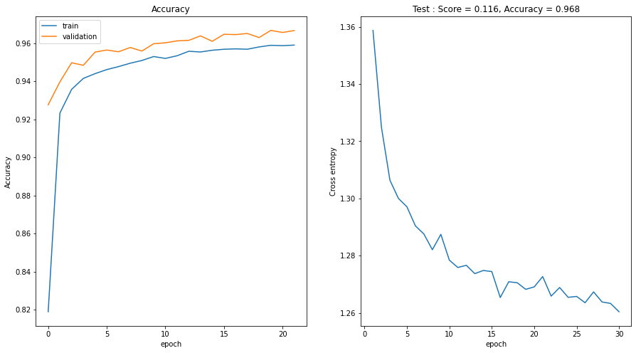

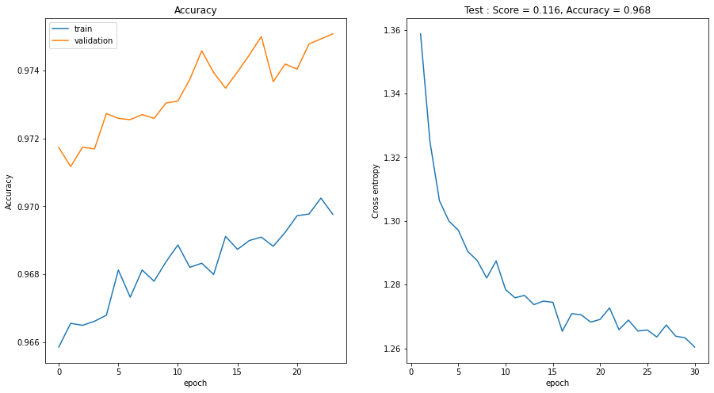

```python
evaluationPlotting(final_model, final_hist.history['accuracy'], final_hist.history['val_accuracy'], score, 30)
evaluationPlotting(final_model_squeeze, final_hist2.history['accuracy'], final_hist2.history['val_accuracy'], score, 30)
```

```python
# Save the model
final_model_squeeze.save("saved_models/final_model_squeeze")
np.save("saved_models/final_model_squeeze/final_hist2.npy", final_hist2.history)
```

```
INFO:tensorflow:Assets written to: saved_models/final_model_squeeze\assets
```

# Final Conclusion

I am confident this model will perform well in the validation by Prof. Barra. Due to its many dropout and in between dense layers I think it has learned a very general and abstract idea of the classes which should make it very robust. 97.83% is obviously great but it has seen the data of this test set. The reason was explained above.

```python
# Export the weights
final_model_squeeze.save_weights("final_submission/final_model_weights.h5")
```

```python
# Summary of final model structure (all kernels are 5x5)
final_model_squeeze.summary()
```

```
Model: "refined_custom_hyperband_cnn"
_________________________________________________________________
Layer (type)                 Output Shape              Param #
=================================================================
conv2d (Conv2D)              (None, 28, 28, 128)       3328
_________________________________________________________________
max_pooling2d (MaxPooling2D) (None, 14, 14, 128)       0
_________________________________________________________________
dropout (Dropout)            (None, 14, 14, 128)       0
_________________________________________________________________
dense (Dense)                (None, 14, 14, 128)       16512
_________________________________________________________________
conv2d_1 (Conv2D)            (None, 14, 14, 80)        256080
_________________________________________________________________
max_pooling2d_1 (MaxPooling2 (None, 7, 7, 80)          0
_________________________________________________________________
dropout_1 (Dropout)          (None, 7, 7, 80)          0
_________________________________________________________________
conv2d_2 (Conv2D)            (None, 7, 7, 96)          192096
_________________________________________________________________
max_pooling2d_2 (MaxPooling2 (None, 4, 4, 96)          0
_________________________________________________________________
dropout_2 (Dropout)          (None, 4, 4, 96)          0
_________________________________________________________________
conv2d_3 (Conv2D)            (None, 4, 4, 64)          153664
_________________________________________________________________
max_pooling2d_3 (MaxPooling2 (None, 2, 2, 64)          0
_________________________________________________________________
dense_1 (Dense)              (None, 2, 2, 32)          2080
_________________________________________________________________
flatten (Flatten)            (None, 128)               0
_________________________________________________________________
dropout_3 (Dropout)          (None, 128)               0
_________________________________________________________________
dense_2 (Dense)              (None, 48)                6192
_________________________________________________________________
dropout_4 (Dropout)          (None, 48)                0
_________________________________________________________________
dense_3 (Dense)              (None, 5)                 245
=================================================================
Total params: 630,197
Trainable params: 630,197
Non-trainable params: 0
_________________________________________________________________
```

```python
print(json.dumps(hyperbandcnn_tuner_refined.get_best_hyperparameters()[0].values, indent=2))
```

```
{
  "num_layers": 4,
  "filters_0": 128,
  "dropout_layer_0": 1,
  "dense_layer_0": 1,
  "dropout_chance_solo": 0.2,
  "dense_layer_end": 1,
  "learning_rate": 0.001,
  "units_dense_middle_0": 128,
  "filters_1": 80,
  "dropout_layer_1": 1,
  "dense_layer_1": 0,
  "filters_2": 96,
  "dropout_layer_2": 1,
  "dense_layer_2": 0,
  "filters_3": 64,
  "dropout_layer_3": 0,
  "dense_layer_3": 1,
  "filters_4": 80,
  "dropout_layer_4": 1,
  "dense_layer_4": 0,
  "units_dense_end_0": 48,
  "dropout_chance_end_0": 0.6,
  "units_dense_end_1": 32,
  "dropout_chance_end_1": 0.7000000000000001,
  "tuner/epochs": 50,
  "tuner/initial_epoch": 17,
  "tuner/bracket": 3,
  "tuner/round": 3,
  "dropout_chance_0": 0.1,
  "dropout_chance_1": 0.1,
  "dropout_chance_2": 0.1,
  "units_dense_middle_3": 32,
  "tuner/trial_id": "e7fb086da571bf246f1fdaad1af16f29"
}
```

```python
# Load model
loaded_model = load_model("saved_models/final_model_squeeze")
# Compute the metrics in test mode
score = loaded_model.evaluate(test_set, verbose=0)
# Print the results
print("Loss: ", score[0], " | Accuracy: ", score[1])
```

```
Loss:  0.05732184275984764  | Accuracy:  0.9783499836921692
```

# Phase 4: Analyzing wrong predictions

As I have mentioned before, a few wrong predicitions in a model can still be no problem. Maybe the fault doesn't lie with the model but with the data or the artist in this case. I think it will prove interesting seeing where the model doesn't predict correctly and see if the image is just drawn very badly.

```python
print("The model class indices are:", training_set.class_indices)
```

```
The model class indices are: {'basket': 0, 'binoculars': 1, 'eye': 2, 'hand': 3, 'rabbit': 4}
```

```python
test_set.reset()
X_test, y_test = next(test_set)
for i in tqdm(range(int(test_set.samples/batch_size)-1)): #1st batch is alread fetched before the for loop
  img, label = next(test_set)
  X_test = np.append(X_test, img, axis=0 )
  y_test = np.append(y_test, label, axis=0)
```

```python
predicted_classes = np.argmax(loaded_model.predict(X_test), axis=-1)
```

```python
y = np.argmax(y_test,axis=1)
labels = (test_set.class_indices)
labels = dict((v,k) for k,v in labels.items())
truth = [labels[k] for k in y]
prediction = [labels[k] for k in predicted_classes]
```

```
Number of errors 432/19968. Here are 60 of them.
```

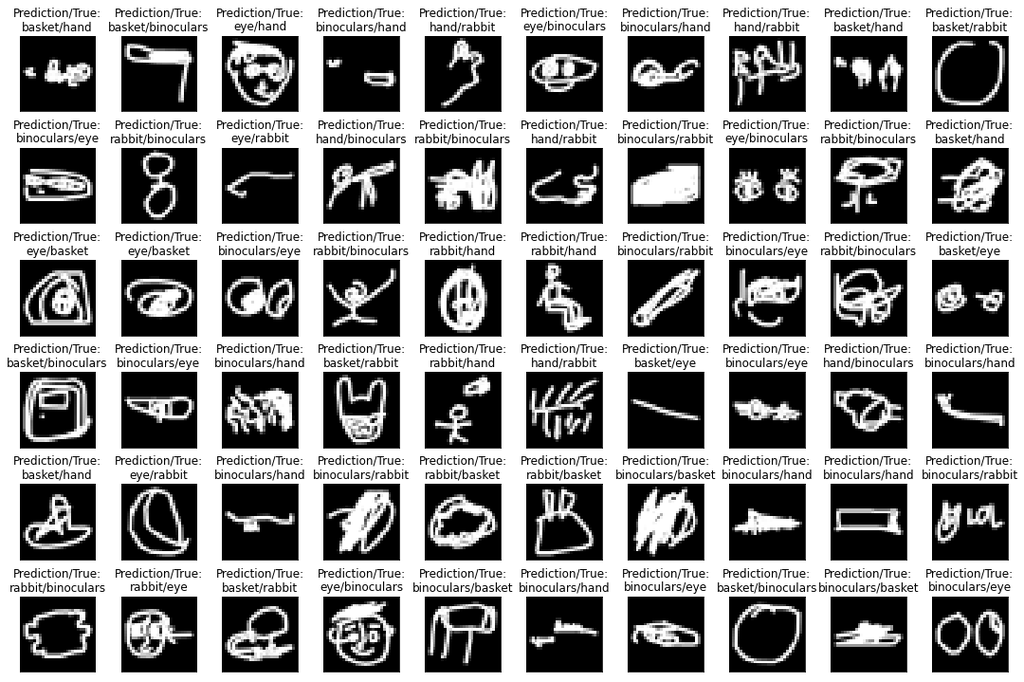

```python
incorrects = np.nonzero(predicted_classes != y)[0]
plt.figure(figsize=(15,10))
for i in range(0,60):
    plt.subplot(6,10,i+1)
    plt.imshow(X_test[incorrects[i]].reshape(28,28), cmap='gray', interpolation='none')
    plt.title( "Prediction/True:\n{}/{}".format(prediction[incorrects[i]], truth[incorrects[i]]))
    plt.xticks([])
    plt.yticks([])
plt.tight_layout()
print("Number of errors {}/{}. Here are 60 of them.".format(incorrects.size,y.size))
```

As we can see there are a bunch of images that are very poorly drawn or falsely labeled. This indicated the model is even better than it's above 95% validation accuracy suggests.

Just because Im curious, here are a few correct predictions:

```
Number of correct predictions 19536/19968. Here are 100 of them.
```

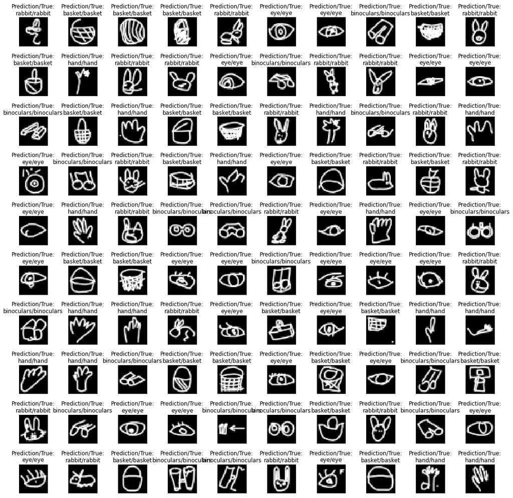

```python
corrects = np.nonzero(predicted_classes == y)[0]
plt.figure(figsize=(15,15))
for i in range(0,100):
    plt.subplot(10,10,i+1)
    plt.imshow(X_test[corrects[i]].reshape(28,28), cmap='gray', interpolation='none')
    plt.title( "Prediction/True:\n{}/{}".format(prediction[corrects[i]], truth[corrects[i]]))
    plt.xticks([])
    plt.yticks([])
plt.tight_layout()
print("Number of correct predictions {}/{}. Here are 100 of them.".format(corrects.size,y.size))
```